Package vignette · gtmeta

# An information-geometric tour of meta-analysis

Pooling studies as a barycenter of Gaussians

Willem M. Otte

## The barycenter idea

`gtmeta` treats a meta-analysis as a problem in the geometry of distributions. Each study enters not as a point estimate plus a standard error, but as its whole estimated Gaussian sampling distribution N(θ<sub>i</sub>, Σ<sub>i</sub>) — a point on the manifold of Gaussians. The pooled result is the distribution that lies closest, on average, to all of them: a weighted average taken *on the curved space* of distributions, then read back as an effect and its uncertainty.

[figure not shown]

N<sub>i</sub> = N(θ<sub>i</sub>, Σ<sub>i</sub>) · one study N · barycenter (pooled estimate)

N = arg min<sub>N</sub> ∑ w<sub>i</sub> d(N, N<sub>i</sub>)²

The geometry — the distance d — is an explicit modelling choice. `gtmeta` implements three: **Bures–Wasserstein** (optimal transport; the closed-form default), **Fisher–Rao** (information geometry), and **Wasserstein–Fisher–Rao** (unbalanced transport, which yields a robust pool). The package is deliberately conservative: wherever a classical meta-analytic limit exists, the geometric estimator is proven — and tested — to reduce to it exactly. This vignette walks that tour: pooling, heterogeneity, inference, diagnostic accuracy, and robustness.

## Univariate quickstart

A study with estimate `yi` and standard error `sei` is the Gaussian N(yi, sei^2). `igmi_studies()` builds the study objects, `igmi_precision_weights()` the usual inverse-variance weights, and `bw_barycenter()` the Bures–Wasserstein Frechet mean by fixed-point iteration.

```r
yi  <- c(0.12, -0.30, 0.25, 0.05, 0.40, -0.10)
sei <- c(0.10,  0.25, 0.15, 0.30, 0.20,  0.12)

studies <- igmi_studies(yi = yi, sei = sei)
w       <- igmi_precision_weights(studies)

fit <- bw_barycenter(studies, weights = w)
c(theta = fit$theta, Sigma = fit$Sigma,
  iterations = fit$iterations, converged = fit$converged)
```

```
#>      theta      Sigma iterations  converged
#> 0.08241437 0.01969837 2.00000000 1.00000000
```

In this scalar case the barycenter mean *is* the fixed-effect estimate — nothing familiar is lost. The pooled `Sigma` is the (weighted) barycenter of the study variances, not the variance of the pooled mean; inference comes later. The underlying distance is available directly:

```r
bw_dist2(studies[[1]], studies[[2]])
```

```
#> [1] 0.1989
```

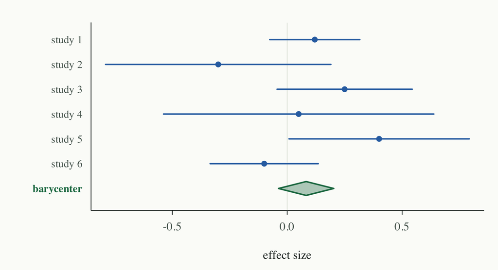

## Heterogeneity: nothing familiar is lost

The Frechet variance — the minimised objective at the barycenter — decomposes exactly into a **location** part (spread of the means) and a **scale** part (spread of the covariances):

```r
fv <- frechet_variance(studies, w)
c(V_F = fv$V_F, V_loc = fv$V_loc, V_scale = fv$V_scale)
```

```
#>         V_F       V_loc     V_scale
#> 0.035088450 0.032230428 0.002858022
```

Calibrating the location part against its known distribution under homogeneity gives the IGMI heterogeneity index `I_F2` and a trace method-of-moments estimator `tr_T_hat` of the between-study variance. In the scalar case these are not analogues of the classical quantities; they are *identical* to them:

```r
het <- igmi_heterogeneity(studies, w)

ee <- metafor::rma(yi = yi, sei = sei, method = "EE")  # Q, Higgins-Thompson
dl <- metafor::rma(yi = yi, sei = sei, method = "DL")  # DerSimonian-Laird

knitr::kable(
  data.frame(
    quantity = c("heterogeneity index", "between-study variance"),
    gtmeta = c(het$I_F2, het$tr_T_hat),
    classical = c(max(0, (ee$QE - (length(yi) - 1)) / ee$QE), dl$tau2),
    row.names = c("I_F^2  =  I^2", "tr T_hat  =  tau^2_DL")
  ),
  digits = 10
)
```

|  | quantity | gtmeta | classical |
| --- | --- | --- | --- |
| I_F^2 = I^2 | heterogeneity index | 0.41679358 | 0.41679358 |
| tr T_hat = tau^2_DL | between-study variance | 0.01794957 | 0.01794957 |

The agreement is exact (to machine precision), not asymptotic: the scalar Bures–Wasserstein geometry *re-derives* Higgins–Thompson I^2 and the DerSimonian–Laird estimator.

## Inference

Three routes to a confidence statement, in increasing order of assumptions dropped:

- `igmi_location_ci()` — exact chi-square region treating the study covariances as known (no heterogeneity);
- `igmi_pivot_ci()` — exact studentized t (Hotelling for m > 1) interval via the Frechet scatter, valid at every K under proportional total covariances; no tau^2 estimate is ever plugged in;
- `igmi_bootstrap()` — nonparametric study resampling.

```r
loc  <- igmi_location_ci(studies, w)
piv  <- igmi_pivot_ci(studies, w)
set.seed(1)
boot <- igmi_bootstrap(studies, w, B = 500)

rbind(location = loc$ci, pivot = piv$ci, bootstrap = as.numeric(boot$theta_ci))
```

```
#>                  [,1]      [,2]
#> location  -0.03775873 0.2025875
#> pivot     -0.12397127 0.2888000
#> bootstrap -0.06247987 0.2297302
```

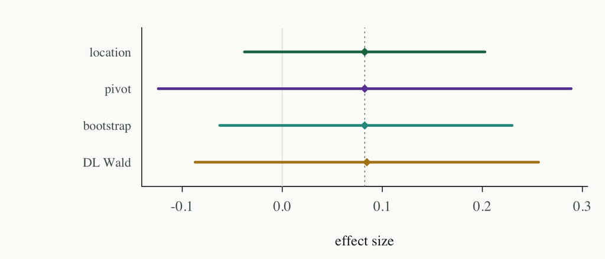

The pivot interval is the one to reach for by default: it is exact at every study count and, unlike Hartung–Knapp–Sidik–Jonkman as usually presented, needs no between-study variance estimate at all.

## Diagnostic test accuracy and the SROC curve

A 2x2 diagnostic study becomes a *bivariate* Gaussian on the (logit sensitivity, logit specificity) plane. Because sensitivity and specificity come from disjoint patient groups, the within-study covariance is exactly diagonal — the within-study correlation that primary reports never provide is 0 *by design*, not a plug-in guess.

The five toy studies below show the classic *threshold effect*: read across them and sensitivity is traded for specificity, so the between-study correlation of the two logits is negative — which is exactly what gives a summary ROC curve its meaning.

```r
tp <- c(96, 88, 85, 76, 70); fn <- c( 4, 12, 15, 24, 30)
fp <- c(28, 20, 14,  9,  5); tn <- c(72, 80, 86, 91, 95)

dta <- igmi_dta_studies(tp = tp, fn = fn, fp = fp, tn = tn)
dta_studies <- lapply(dta, function(s) igmi_gaussian(s$theta, s$Sigma))

dta_fit <- bw_barycenter(dta_studies)
dta_fit$theta
```

```
#> [1] 1.781012 1.880824
```

```r
plogis(dta_fit$theta)          # summary sensitivity and specificity
```

```
#> [1] 0.8558218 0.8677057
```

The between-study covariance comes from the matrix method-of-moments estimator, and the summary ROC curve is read directly off the pooled Gaussian — by construction it coincides with the Reitsma bivariate-model SROC at the same parameters:

```r
T_hat <- igmi_mm_cov(dta_studies)$T_hat
sr <- igmi_sroc(dta_fit, T_hat)
attr(sr, "summary_point")
```

```
#>      sens      spec
#> 0.8558218 0.8677057
```

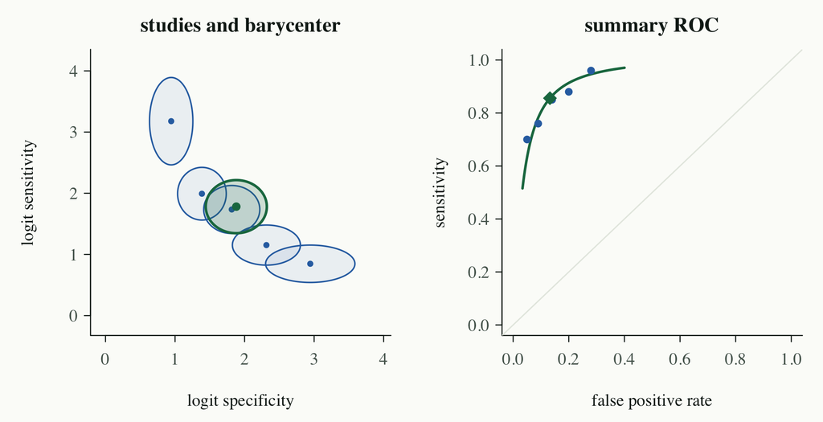

## The Wasserstein–Fisher–Rao robustness dial

Unbalanced transport may *destroy* mass rather than move it. For the WFR pool this becomes a single robustness tuning constant: a length scale `delta` such that a study farther than pi * delta from the consensus stops counting entirely. The one-atom WFR Frechet mean is exactly the Andrews-sine redescending M-estimator, and as `delta -> Inf` it recovers the fixed-effect mean — the dial interpolates from classical pooling to full outlier rejection. (This section uses the pure-R solver; the optional Python bridge is never needed.)

```r
set.seed(21)
dat <- sim_contaminated(k = 12, mu = 0.3, eps = 0.25, shift = 3)
dat[dat$is_outlier, c("yi", "sei")]
```

```
#>         yi       sei
#> 2 3.378984 0.2009782
#> 3 3.313957 0.3797009
#> 6 2.817528 0.4674734
```

```r
robust <- wfr_pool(dat$yi, dat$sei, delta = 0.5)
c(estimate = robust$estimate, se = robust$se,
  mass_ratio = robust$mass_ratio, n_active = robust$n_active)
```

```
#>   estimate         se mass_ratio   n_active
#> 0.28700147 0.05369795 0.59934956 9.00000000
```

```r
naive <- wfr_pool(dat$yi, dat$sei, delta = Inf)   # = fixed effect
c(robust = robust$estimate, naive = naive$estimate, truth = 0.3)
```

```
#>    robust     naive     truth
#> 0.2870015 0.8694082 0.3000000
```

The retained-mass fraction `mass_ratio` is a built-in contamination diagnostic: mass is reported as destroyed, never silently renormalised.

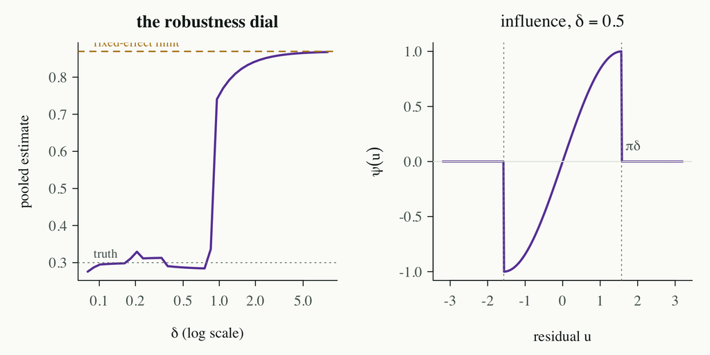

## Classical benchmarks

The classical estimators ship alongside the geometric ones, so every comparison in this vignette can be reproduced without leaving the package:

```r
bm <- benchmark_models(yi, sei)
knitr::kable(bm[, c("model", "estimate", "se", "ci.lb", "ci.ub",
                    "scale_par", "scale", "AIC", "BIC")],
             digits = 4, row.names = FALSE)
```

| model | estimate | se | ci.lb | ci.ub | scale_par | scale | AIC | BIC |
| --- | --- | --- | --- | --- | --- | --- | --- | --- |
| FE | 0.0824 | 0.0613 | -0.0378 | 0.2026 | phi | 1.0000 | 0.5612 | 0.3530 |
| RE(ML) | 0.0840 | 0.0736 | -0.0603 | 0.2282 | tau2 | 0.0071 | 2.3785 | 1.9620 |
| UWLS | 0.0824 | 0.0803 | -0.1240 | 0.2888 | phi | 1.7147 | 2.1293 | 1.7128 |

And the headline reduction, stated as code:

```r
all.equal(unname(fit$theta), bm$estimate[bm$model == "FE"])
```

```
#> [1] TRUE
```

## Where to go next

- **Bures–Wasserstein** (`bw_barycenter()`) is the closed-form default; its barycenter mean is the fixed-effect estimate.
- **Fisher–Rao** (`fr_mean()`, `fr_karcher_check()`) is reported within its proven uniqueness region.
- **Wasserstein–Fisher–Rao** (`wfr_pool()`) turns unbalanced transport into a principled robustness dial.

Multivariate pooling (`igmi_studies(theta = , Sigma = )`), prediction-model meta-analysis (`igmi_pred_studies()`), simulation generators (`sim_meta()`, `sim_multivariate()`, `sim_network()`), and Cochrane-style data adapters (`cochrane_tidy()`, `igmi_study_list()`) follow the same pattern: build Gaussian study objects, choose a geometry, pool.

Every estimator here is anchored to a numbered theorem and tested against it in `tests/testthat/` — the test suite is the package’s second vignette.